# Symbolic Math - A Workflow

http://www.hippasus.com/resources/symmath/maximasym.html

## Sympy - Using its symbolic math capabilities

### Configurando o Ambiente:

```python
from sympy import *
init_session()
a, b, c, d = symbols('a, b, c, d')
```

```
IPython console for SymPy 1.7.1 (Python 3.7.10-64-bit) (ground types: python)

These commands were executed:
>>> from __future__ import division
>>> from sympy import *
>>> x, y, z, t = symbols('x y z t')
>>> k, m, n = symbols('k m n', integer=True)
>>> f, g, h = symbols('f g h', cls=Function)
>>> init_printing()

Documentation can be found at https://docs.sympy.org/1.7.1/
```

```python
from seaborn import set_style as plot_style
plot_style("whitegrid")
%matplotlib inline
```

```python
from IPython.core.interactiveshell import InteractiveShell
InteractiveShell.ast_node_interactivity = "all"
```

### Math capabilities

Basic typing:

```python
(2+S(5)/6-sqrt(4))**2
```

$\displaystyle \frac{25}{36}$

Using the previous line:

```python
_ + 1
```

$\displaystyle \frac{61}{36}$

Using a line by name:

```python
Out[5]+1
```

$\displaystyle \frac{97}{36}$

Numeric evaluation:

```python
N(_)
```

$\displaystyle 2.69444444444444$

Defining a function:

```python
f = Lambda(x, x**2 - 5*x + 6)
f
```

$\displaystyle \left( x \mapsto x^{2} - 5 x + 6 \right)$

Using a function:

```python
f(5)
```

$\displaystyle 6$

Assigning a value to a variable:

```python
a = 5
a
```

$\displaystyle 5$

Use the variable:

```python
f(a)
```

$\displaystyle 6$

Defining an equation:

```python
e = Eq(x, 1-b*y)
e
```

$\displaystyle x = - b y + 1$

Solving an equation:

```python
solveset(e , y)
```

$\displaystyle \left\{- \frac{x - 1}{b}\right\}$

Solve for any of its variables:

```python
solveset(e , b)
```

$\displaystyle \left\{- \frac{x - 1}{y}\right\}$

Roots of a quadratic equation:

```python
solveset(x**2 + 2*x - 3, x)
```

$\displaystyle \left\{-3, 1\right\}$

```python
roots(x**2 + 2*x - 3, x)
```

$\displaystyle \left\{ -3 : 1, \ 1 : 1\right\}$

Extract result from a solve output list:

```python
s = [*solveset(x**2 + 2*x - 3, x)]
s[0]
```

$\displaystyle -3$

Plotting a function:

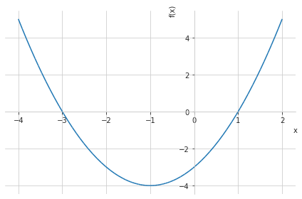

```python
plot(x**2 + 2*x - 3, (x, -4, 2));
```

Systems of equations:

```python
linsolve([x+3*y-3,2*x+5*y-5],[x,y])
```

$\displaystyle \left\{\left( 0, \ 1\right)\right\}$

Plotting multiple functions:

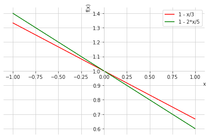

```python
p = plot((3-x)/3, (5-2*x)/5, (x,-1,1), show=False);
p[0].line_color = "r"
p[1].line_color = "g"
p.legend=True
p.show()
```

Solving equations numerically:

```python
f = x**7 - 5*x**6 + 4*x**4 - 5*x**2 + x + 2
f
```

$\displaystyle x^{7} - 5 x^{6} + 4 x^{4} - 5 x^{2} + x + 2$

```python
nsolve(f, x, 0)
```

$\displaystyle 0.819421363496412$

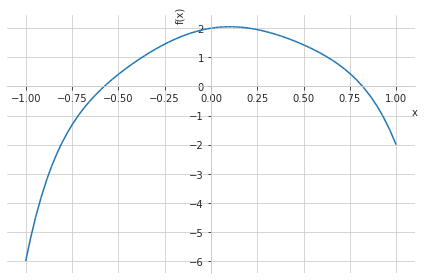

```python
plot(f, (x,-1,1));
```

Functions of multiple variables:

```python
f = Lambda((x,y), sin(x**2+y**2))
f
```

$\displaystyle \left( \left( x, \ y\right) \mapsto \sin{\left(x^{2} + y^{2} \right)} \right)$

Using a function of multiple variables:

```python
f(1,4)
```

$\displaystyle \sin{\left(17 \right)}$

Force a numerically result:

```python
f(1,4).evalf(3)
```

$\displaystyle -0.961$

3D Plots:

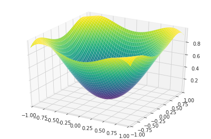

```python
plotting.plot3d(f(x,y),(x,-1,1),(y,-1,1));
```

Factoring Polynomials:

```python
factor(x**2 + 2*x + 1)
```

$\displaystyle \left(x + 1\right)^{2}$

Expanding Polynomials:

```python
expand(_)
```

$\displaystyle x^{2} + 2 x + 1$

Simplifying Trigonometric expressions:

```python
trigsimp(sin(x)**2 + cos(x)**2)
```

$\displaystyle 1$

Simplifying Trigonometric by methods:

```python
t = (4*cos(y)**3 - 3*cos(y))*cos(x)
t
trigsimp(t)
trigsimp(t, method='old')
trigsimp(t, method='groebner')
trigsimp(t, method='combined')
simplify(t)
```

$\displaystyle \left(4 \cos^{3}{\left(y \right)} - 3 \cos{\left(y \right)}\right) \cos{\left(x \right)}$

$\displaystyle \cos{\left(x \right)} \cos{\left(3 y \right)}$

$\displaystyle \cos{\left(x \right)} \cos{\left(3 y \right)}$

$\displaystyle 4 \cos{\left(x \right)} \cos^{3}{\left(y \right)} - 3 \cos{\left(x \right)} \cos{\left(y \right)}$

$\displaystyle \frac{\cos{\left(x - 3 y \right)}}{2} + \frac{\cos{\left(x + 3 y \right)}}{2}$

$\displaystyle \frac{\cos{\left(x - 3 y \right)}}{2} + \frac{\cos{\left(x + 3 y \right)}}{2}$

Expanding Trigonometric expressions:

```python
e = cos(x+3*y)
e
```

$\displaystyle \cos{\left(x + 3 y \right)}$

```python
expand_trig(e)
expand(e, trig=True)
```

$\displaystyle - \left(- 4 \sin^{3}{\left(y \right)} + 3 \sin{\left(y \right)}\right) \sin{\left(x \right)} + \left(4 \cos^{3}{\left(y \right)} - 3 \cos{\left(y \right)}\right) \cos{\left(x \right)}$

$\displaystyle 4 \sin{\left(x \right)} \sin^{3}{\left(y \right)} - 3 \sin{\left(x \right)} \sin{\left(y \right)} + 4 \cos{\left(x \right)} \cos^{3}{\left(y \right)} - 3 \cos{\left(x \right)} \cos{\left(y \right)}$

Simplifying rational expressions:

```python
e = ((x**2 + 2*x + 1)/(x+1) + 1/(4*x+3))
e
```

$\displaystyle \frac{1}{4 x + 3} + \frac{x^{2} + 2 x + 1}{x + 1}$

```python
Eq(e, together(e))
```

$\displaystyle \frac{1}{4 x + 3} + \frac{x^{2} + 2 x + 1}{x + 1} = \frac{x + \left(4 x + 3\right) \left(x^{2} + 2 x + 1\right) + 1}{\left(x + 1\right) \left(4 x + 3\right)}$

```python
Eq(e, cancel(e))
```

$\displaystyle \frac{1}{4 x + 3} + \frac{x^{2} + 2 x + 1}{x + 1} = \frac{4 x^{2} + 7 x + 4}{4 x + 3}$

```python
Eq(e, apart(e))
```

$\displaystyle \frac{1}{4 x + 3} + \frac{x^{2} + 2 x + 1}{x + 1} = x + 1 + \frac{1}{4 x + 3}$

Expanding rational expressions:

```python
e = (x**2-1)/(x+2)
Eq(e, expand(e))
```

$\displaystyle \frac{x^{2} - 1}{x + 2} = \frac{x^{2}}{x + 2} - \frac{1}{x + 2}$

Substitutions:

```python
(x**2 + 1).subs(x, 2)
```

$\displaystyle 5$

Substituting the Results of One Calculation Into Another:

```python
solveset(x**2-1, x)
```

$\displaystyle \left\{-1, 1\right\}$

```python
s = [*solveset(x**2-1, x)]
x_1 = {x: s[0]}
x_2 = {x: s[1]}
```

```python
e = Eq(y, 3*x-11)
e
```

$\displaystyle y = 3 x - 11$

```python
e.subs(x_1)
e.subs(x_2)
```

$\displaystyle y = -14$

$\displaystyle y = -8$

Calculate a limit:

```python
f = sin(x)/x
limit(f, x, 0)
```

$\displaystyle 1$

Calculate a limit as x approaches from dir="+":

```python
f = tan(x)
limit(f, x, pi/2, dir='+')
```

$\displaystyle -\infty$

Calculate a limit as x approaches from dir="-":

```python
f = tan(x)
limit(f, x, pi/2, dir='-')
```

$\displaystyle \infty$

Show the Limit Equation:

```python
e = Limit(sin(x)/x, x, 0)
Eq(e, e.doit())
```

$\displaystyle \lim_{x \to 0^+}\left(\frac{\sin{\left(x \right)}}{x}\right) = 1$

Simple Differentiation:

```python
f = c*x**2-sin(d*x)
diff(f, x)
```

$\displaystyle 2 c x - d \cos{\left(d x \right)}$

Higher Order Differentiation:

```python
diff(f, x, 3)
```

$\displaystyle d^{3} \cos{\left(d x \right)}$

Partial Differentiation:

```python
diff(f, d, 3)
```

$\displaystyle x^{3} \cos{\left(d x \right)}$

Show Derivative Equation:

```python
e = Derivative(c*x**2-sin(d*x), x, 2)
Eq(e, e.doit())
```

$\displaystyle \frac{\partial^{2}}{\partial x^{2}} \left(c x^{2} - \sin{\left(d x \right)}\right) = 2 c + d^{2} \sin{\left(d x \right)}$

Simple Integration:

```python
integrate(cos(3*x),x)
```

$\displaystyle \frac{\sin{\left(3 x \right)}}{3}$

Definite Integration:

```python
integrate(cos(3*x),(x, 0, pi/2))
```

$\displaystyle - \frac{1}{3}$

Numeric Integration:

```python
integrate(sin(sin(x)),(x,0,1))
```

$\displaystyle \int\limits_{0}^{1} \sin{\left(\sin{\left(x \right)} \right)}\, dx$

```python
N(_)
```

$\displaystyle 0.430606103120691$

Show a Integral Equation:

```python
e = Integral(sin(x),(x, 0, pi))
Eq(e, e.doit())
```

$\displaystyle \int\limits_{0}^{\pi} \sin{\left(x \right)}\, dx = 2$

Multiple Integrals:

```python
e = Integral(sin(x)+cos(y),(x, 0, pi), (y, 0, 2*pi))
Eq(e, e.doit())
```

$\displaystyle \int\limits_{0}^{2 \pi}\int\limits_{0}^{\pi} \left(\sin{\left(x \right)} + \cos{\left(y \right)}\right)\, dx\, dy = 4 \pi$

Summation:

```python
Sum(1/n**2, (n, 1, oo))
```

$\displaystyle \sum_{n=1}^{\infty} \frac{1}{n^{2}}$

Total of sum:

```python
e = Sum(1/n**2, (n, 1, oo))
Eq(e, e.doit())
```

$\displaystyle \sum_{n=1}^{\infty} \frac{1}{n^{2}} = \frac{\pi^{2}}{6}$

Products:

```python
Product(1/n**2, (n, 1, oo))
```

$\displaystyle \prod_{n=1}^{\infty} \frac{1}{n^{2}}$

Total of products:

```python
product(1/n**2, (n, 1, 10))
```

$\displaystyle \frac{1}{13168189440000}$

Show a product equation:

```python
e = Product(1/n**2, (n, 1, 10))
Eq(e, e.doit())
```

$\displaystyle \prod_{n=1}^{10} \frac{1}{n^{2}} = \frac{1}{13168189440000}$

Series Expansion

```python
taylor_sin = series(sin(x),x, 0, 6)
taylor_sin
```

$\displaystyle x - \frac{x^{3}}{6} + \frac{x^{5}}{120} + O\left(x^{6}\right)$

Removes the additive O(...) symbol:

```python
sin_approx = taylor_sin.removeO()
```

Compare series approximation to the original function:

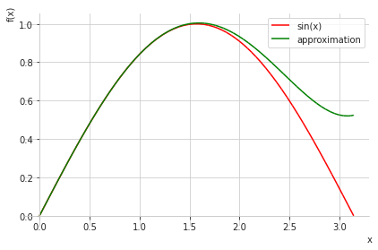

```python
p = plot(sin(x), sin_approx, (x, 0, pi), show=False);
p[0].line_color = "r"
p[1].line_color = "g"
p[1].label = "approximation"
p.legend = True
p.show()
```